# ECON 424 HW4 R Exericises

YUANJIAN ZHOU

Feb 22,2020

# A

## 1

```r
ma1 = function(theta) {
  # generate
  ma_model = list(ma = theta)
  set.seed(1)
  ma1 = arima.sim(ma_model, n = 250, mean = 0, sd = 0.01) + 0.05 # simulated series
  ma1_acf_theoretical = ARMAacf(ma = theta, lag.max = 20) # theoretical ACF
  ma1_acf_sample = acf(ma1, lag.max = 20, plot = F)$acf # sample ACF

  # plot
  par(mfrow = c(3, 1))
  plot(ma1,
       ylab = "Yt",
       main =  str_c("MA(1) process with theta = ", theta))
  plot(
    1:21,
    ma1_acf_theoretical,
    type = "h",
    col = "blue",
    main = str_c("Theoretical ACF of MA(1) ：theta = ", theta),
    xlab = "lag",
    ylab = "rho"
  )
  abline(h = 0)
  plot(
    1:21,
    ma1_acf_sample,
    type = "h",
    col = "blue",
    main = str_c("Sample ACF of MA(1) ：theta = ", theta),
    xlab = "lag",
    ylab = "rho"
  )
  abline(h = 0)
}
```

### (a)

- MA(1) with $\theta = 0.5$

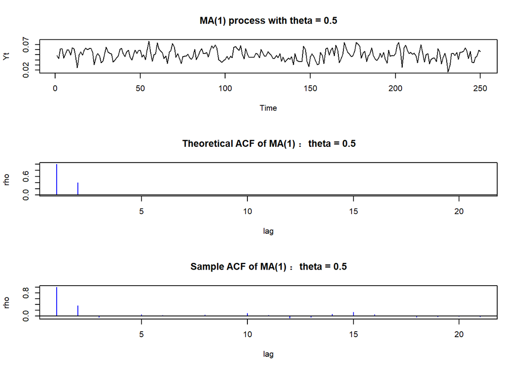

```r
ma1(0.5)
```

- MA(1) with $\theta = 0.9$

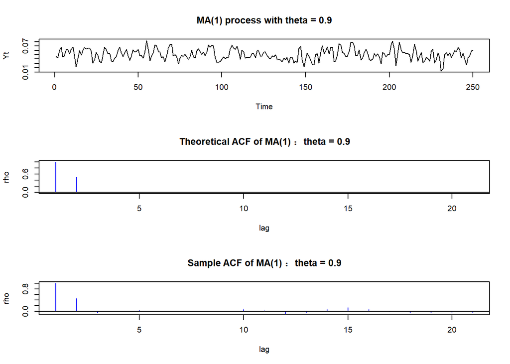

```r
ma1(0.9)
```

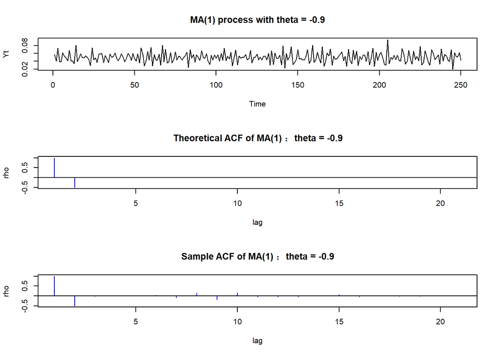

```r
ma1(-0.9)
```

### (b)

- The simulated series behaves well, there is no much time dependence, and the sample ACF shows the same pattern with theoretical ACF: only has a statistically significant non-zero value at lag = 1.

## 2

```r
# generate
ar1 = function(phi) {
  ar_model = list(ar = phi)
  set.seed(46)
  mu = 0.05
  ar1 = arima.sim(ar_model, n = 250, mean = 0, sd = 0.1) + mu
  ar1_acf_theoretical = ARMAacf(ar = phi, lag.max = 20)
  ar1_acf_sample = acf(ar1, lag.max = 20, plot = F)$acf

#plot
  par(mfrow = c(3, 1))
  plot(ar1,
       ylab = "Yt",
       main =  str_c("AR(1) process with phi = ",  phi))
  plot(
    1:21,
    ar1_acf_theoretical,
    type = "h",
    col = "blue",
    main = str_c("Theoretical ACF of MA(1) ：phi = ", phi),
    xlab = "lag",
    ylab = "rho"
  )
  abline(h = 0)
  plot(
    1:21,
    ar1_acf_sample,
    type = "h",
    col = "blue",
    main = str_c("Sample ACF of AR(1) ：phi = ", phi),
    xlab = "lag",
    ylab = "rho"
  )
  abline(h = 0)
}
```

### (a)

- AR(1) with $\phi = 0$

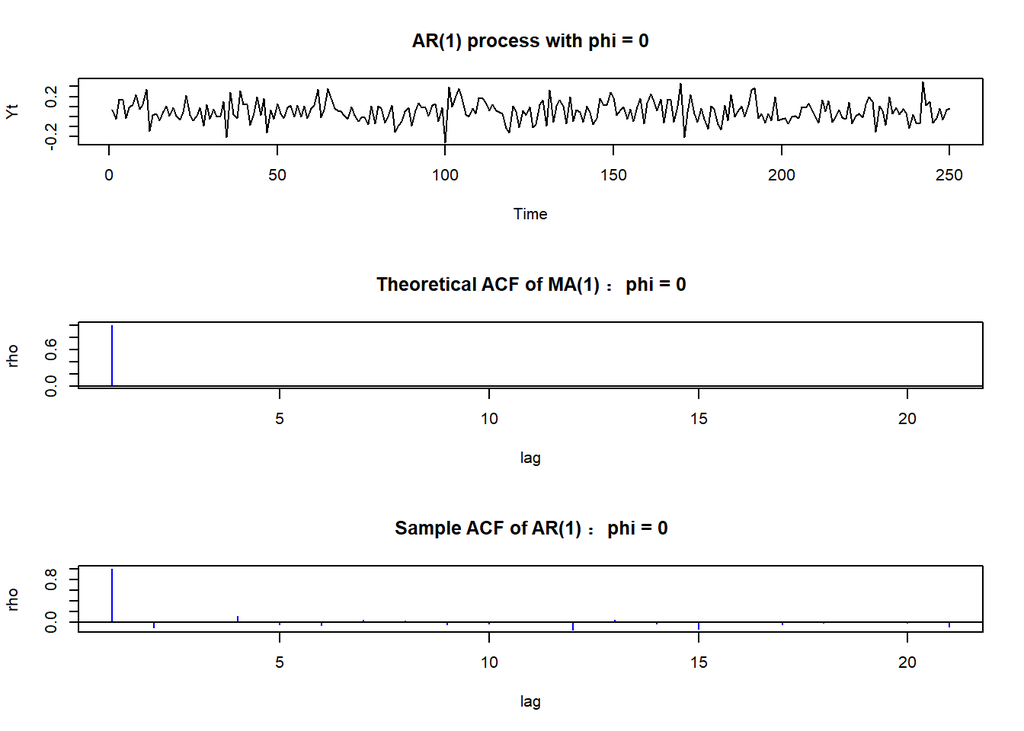

```r
ar1(0)
```

- AR(1) with $\phi = 0.5$

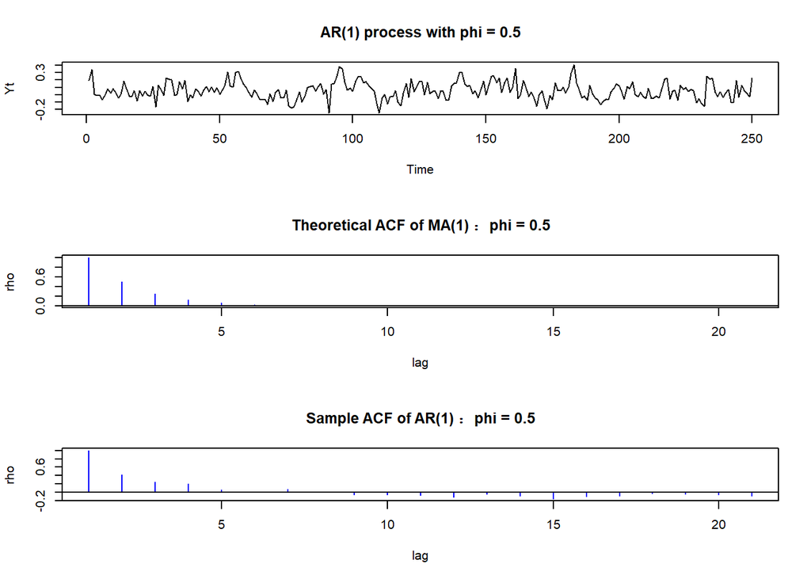

```r
ar1(0.5)
```

- AR(1) with $\phi = 0.9$

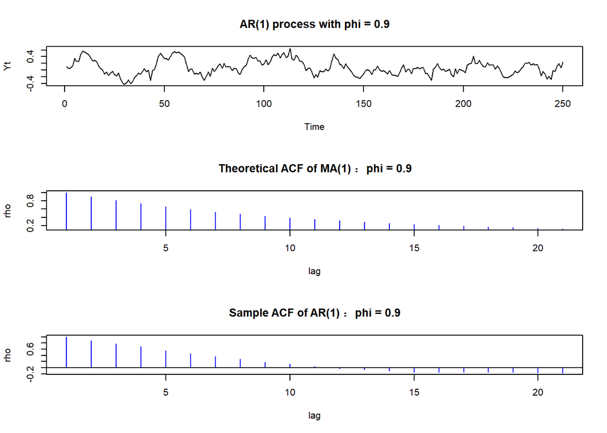

```r
ar1(0.9)
```

- AR(1) with $\phi = 0.99$

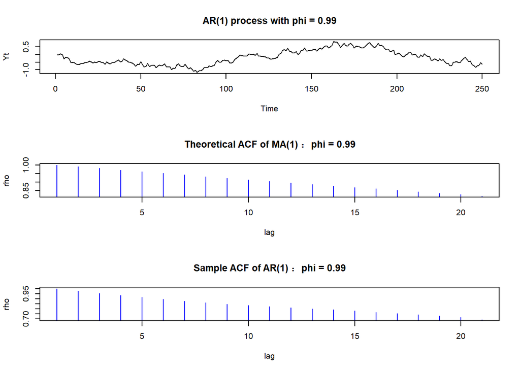

```r
ar1(0.99)
```

### (b)

- With the increase of $\phi$, the time dependence is also increasing, which can be seen both from the time-series plot and ACF plot. As we can see, the sample ACF is quite similar to the theoretical ones. AR(1) with $\phi = 0.99$ is close to non-stationary series.

# B

```r
library(zoo)
library(PerformanceAnalytics)
library(tseries)
library(car)
```

## 0

- VBLTX: This index fund offers a low-cost, diversified approach to bond investing, providing broad exposure to U.S. investment-grade bonds with maturities of more than ten years, with 60% in coporate bond and 40% in government bond. Because of the long maturities, this index is sensitive to changes of interest rate.
- FMAGX: This fund normally invests in common stocks, like MSFT and AAPL. It will invest in either “growth” stock or “value” stock or both. Because it mainly invests in stocks, it is sensitive to stock market risk.
- SBUX: This the stock of Starbucks Corporation, which together with its subsidiaries, operates as a roaster, marketer, and retailer of specialty coffee worldwide.

### preparation

```r
# use api to get historic data from yahoo
get_price = function(tick) {
  result = suppressWarnings(
    get.hist.quote(
      instrument = tick,
      quote = "AdjClose",
      provider = "yahoo",
      start = "1998-01-01",
      end = "2009-12-31",
      compression = "m",
      retclass = "zoo"
    )
  )
  return(result)
}


VBLTX = get_price("VBLTX")
```

```
## time series ends   2009-12-01
```

```r
FMAGX = get_price("FMAGX")
```

```
## time series ends   2009-12-01
```

```r
SBUX  = get_price("SBUX")
```

```
## time series ends   2009-12-01
```

```r
data_price = merge.zoo(VBLTX, FMAGX, SBUX) # merge zoo objects with same index
colnames(data_price) = c("VBLTX", "FMAGX", "SBUX")
# change index to Month-Year format, like Mar 1995
index(data_price) = as.yearmon(index(data_price), "%B%y")
# rt = lnpt - lnpt-1
data_ccreturn = diff(log(data_price))
```

## 1

### (a)

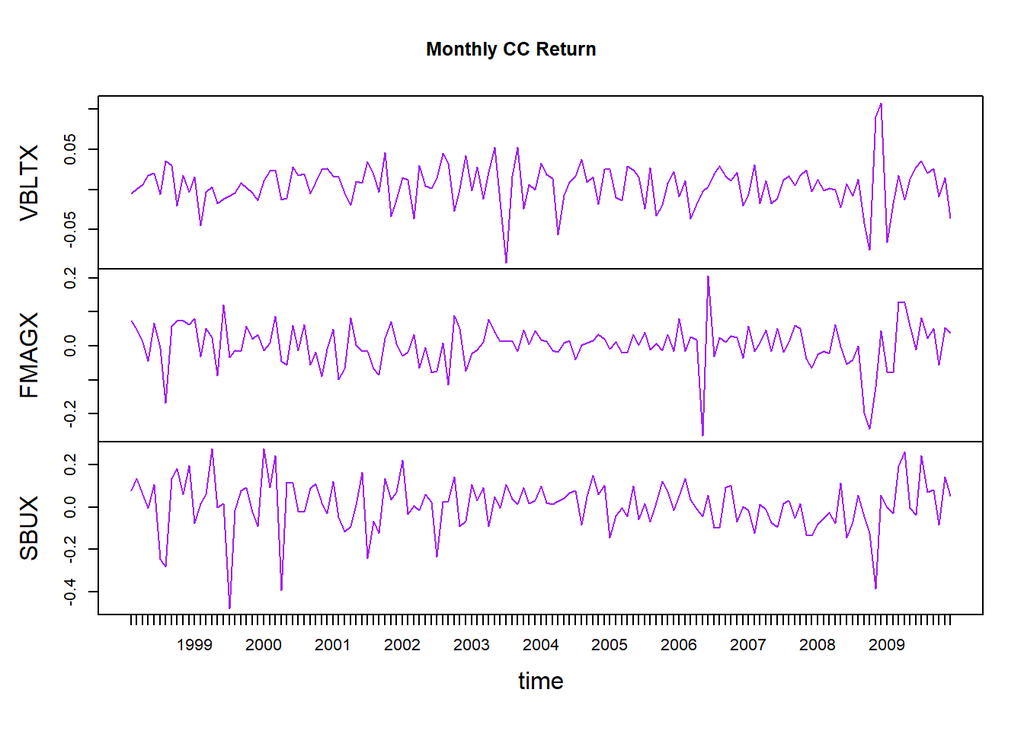

```r
plot(data_ccreturn,
     main = "Monthly CC Return",
     xlab = "time",
     col = "purple")
```

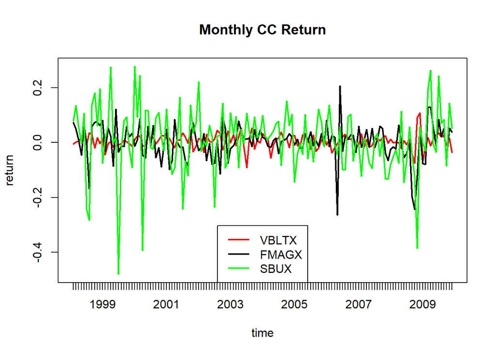

```r
plot(
  data_ccreturn,
  plot.type = "single",
  main = "Monthly CC Return",
  xlab = "time",
  ylab = "return",
  col = c("red", "black", "green"),
  lwd = 2
)
legend(
  "bottom",
  legend = c("VBLTX", "FMAGX", "SBUX"),
  col = c("red", "black", "green"),
  lwd = 2
)
```

### (b)

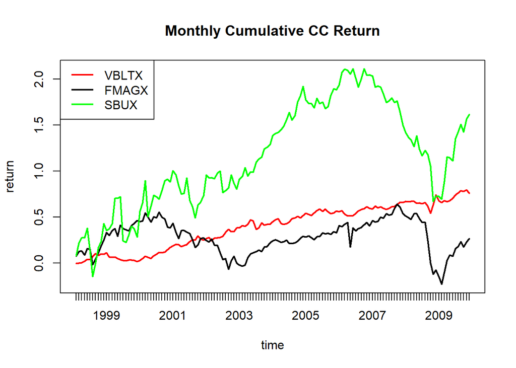

```r
data_ccreturn_cum = cumsum(data_ccreturn)
plot(
  data_ccreturn_cum,
  plot.type = "single",
  main = "Monthly Cumulative CC Return",
  xlab = "time",
  ylab = "return",
  col = c("red", "black", "green"),
  lwd = 2
)
legend(
  "topleft",
  legend = c("VBLTX", "FMAGX", "SBUX"),
  col = c("red", "black", "green"),
  lwd = 2
)
```

- From the plots, we can see that SBUX has a highest cumulative cc return after 2001. Besides, the cumulative cc return of VBLTX is more stable than others, and there seems to exist a positive relationship between the cumulative cc return of VBLTX and FMAGX after 2003.
- Over the investment horizon, SBUX gave the best future value, FMAGX gave the worst one.

### (c)

```r
data_ccreturn_m = as.matrix(data_ccreturn) # some basic function do not work for dataframe

fourplots = function(tick) {
  par(mfrow = c(2, 2))
  data = data_ccreturn_m[, tick]
  #histogram
  hist(
    data,
    main = "Histogram",
    xlab = tick,
    probability = T,
    col = "purple"
  )

  # boxplot
  boxplot(data,
          main = "Boxplot",
          col = "purple",
          xlab = tick)

  # density plot
  plot(
    density(data),
    type = "l",
    main = "Denstiy Plot",
    xlab = "monthly cc return",
    ylab = "probability",
    col = "purple"
  )

  # qqplot
  qqPlot( ~ data,
          col = "purple",
          ylab = "sample quantitles",
          main = "QQ plot")
}
```

- VBLTX

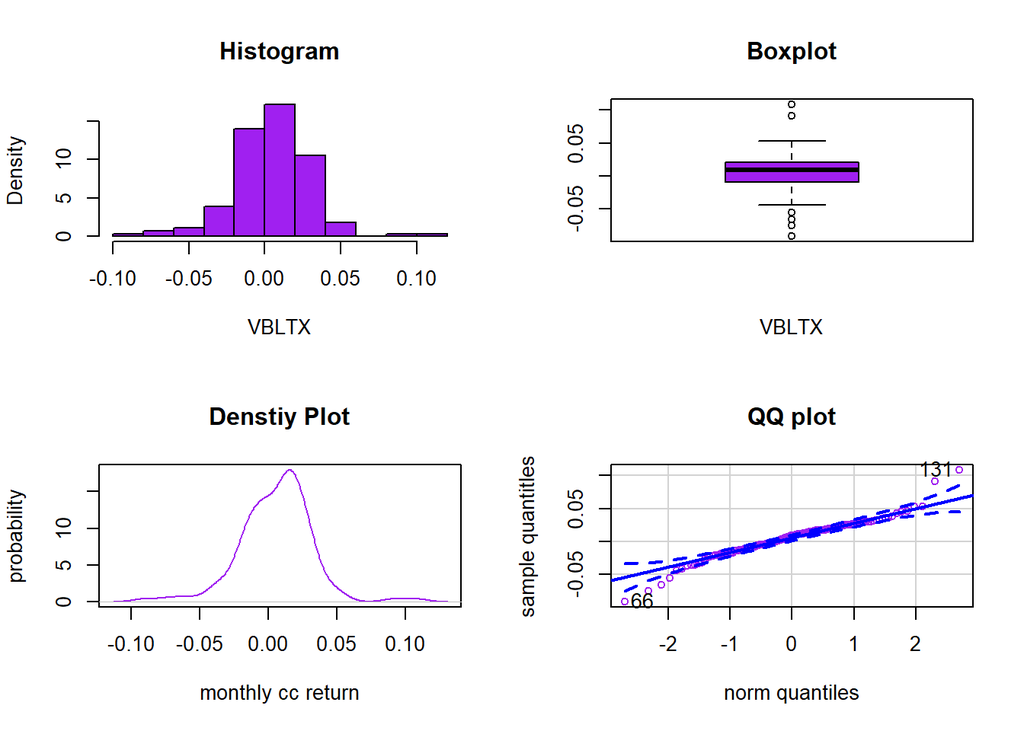

```
## [1] 131  66
```

```r
fourplots("VBLTX")
```

- The return distribution of VBLTX looks like normal distribution despite of another small peak. According to normal QQ-plot, it is similar to normal distribution while having long tails.
- FMAGX

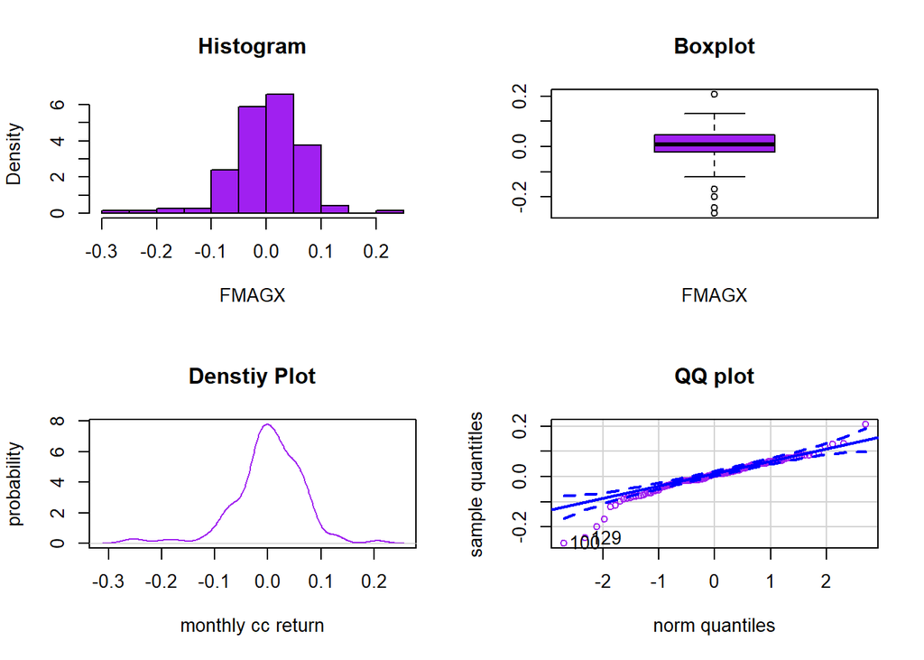

```
## [1] 100 129
```

```r
fourplots("FMAGX")
```

- The distribution of return of FMAGX just has a peak and shape is similar to normal distribution, but it has a long left tail, which can also be found in the QQ plot.
- SBUX

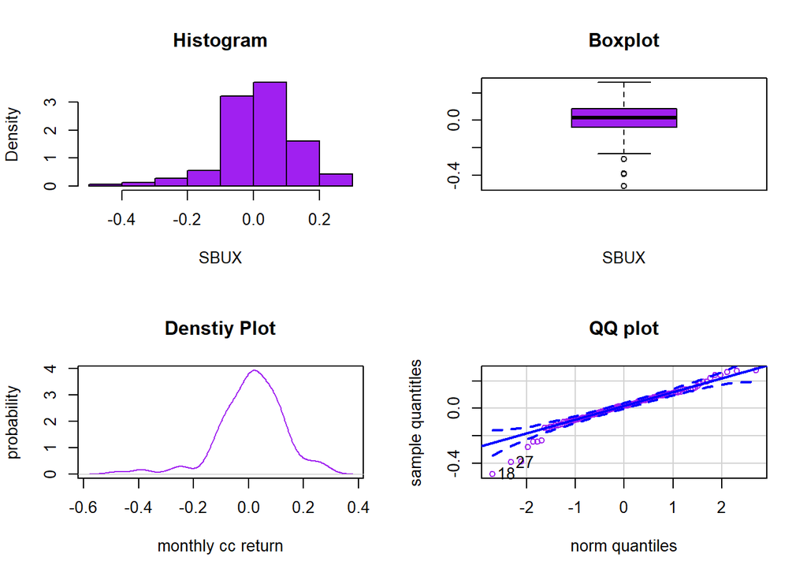

```
## [1] 18 27
```

```r
fourplots("SBUX")
```

- Similar to FMAGX, SBUX has a normal-like shape while having a long left-tail.
- Comparison between distributions

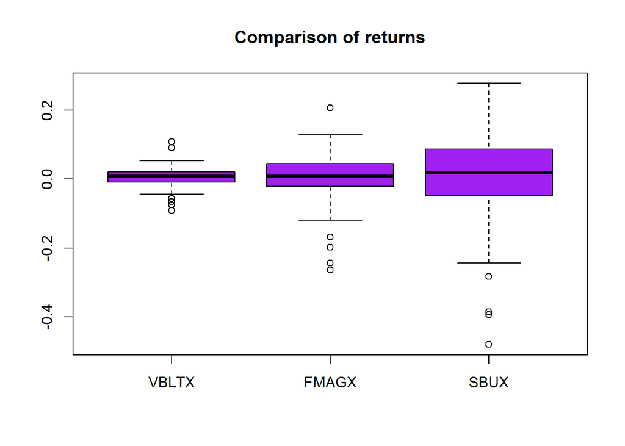

```r
boxplot(data_ccreturn_m, col = "purple", main = "Comparison of returns")
```

- Comparing the distrbution of 3 assets, we find that they have similar median, while SBUX has a largest variance, and VBLTX has a smallest variance.

### (d)

```r
summary(data_ccreturn)
```

```
##      Index          VBLTX               FMAGX                SBUX
##  Min.   :1998   Min.   :-0.091379   Min.   :-0.264297   Min.   :-0.47970
##  1st Qu.:2001   1st Qu.:-0.009577   1st Qu.:-0.021240   1st Qu.:-0.04883
##  Median :2004   Median : 0.008555   Median : 0.008247   Median : 0.01815
##  Mean   :2004   Mean   : 0.005302   Mean   : 0.001856   Mean   : 0.01132
##  3rd Qu.:2007   3rd Qu.: 0.020382   3rd Qu.: 0.045026   3rd Qu.: 0.08676
##  Max.   :2010   Max.   : 0.108267   Max.   : 0.206864   Max.   : 0.27732
```

```r
apply(data_ccreturn, 2, mean)
```

```
##       VBLTX       FMAGX        SBUX
## 0.005302105 0.001856141 0.011318308
```

```r
apply(data_ccreturn, 2, var)
```

```
##        VBLTX        FMAGX         SBUX
## 0.0006902688 0.0041077189 0.0142544638
```

```r
apply(data_ccreturn, 2, sd)
```

```
##      VBLTX      FMAGX       SBUX
## 0.02627297 0.06409149 0.11939206
```

```r
apply(data_ccreturn, 2, skewness)
```

```
##      VBLTX      FMAGX       SBUX
## -0.1470246 -0.9283864 -0.9060688
```

```r
apply(data_ccreturn, 2, kurtosis, method = "moment")
```

```
##    VBLTX    FMAGX     SBUX
## 5.887121 6.397671 5.694740
```

- MEAN: SBUX>VBLTX>FMAGX.
- VARIANCE, STANDARD DEVIATION: SBUX>FMAGX>VBLTX
- SKEWNESS: 3 aseets are all negative-biased, FMAGX and SBUX are more severe than VBLTX.
- KURTOSIS: 3 assets are all sharper than normal distribution, and FMAGX is the sharpest.
- SBUX appears to be the riskest asset.

### (e)

```r
data_ccreturn_annual = 12 * apply(data_ccreturn, 2, mean) # annual cc return
data_sreturn_annual = exp(data_ccreturn_annual) - 1 # annual simple return
print(data_ccreturn_annual)
```

```
##      VBLTX      FMAGX       SBUX
## 0.06362526 0.02227369 0.13581969
```

```r
print(data_sreturn_annual)
```

```
##      VBLTX      FMAGX       SBUX
## 0.06569296 0.02252360 0.14547534
```

- It suprises me that annual cc returns and simple returns are quite similar.

### (f)

```r
sqrt(12) * apply(data_ccreturn, 2, sd) # annual cc return standard deviation
```

```
##      VBLTX      FMAGX       SBUX
## 0.09101223 0.22201943 0.41358622
```

- The magnitude of the standard deviation is large according to the mean annual return.

### (g)

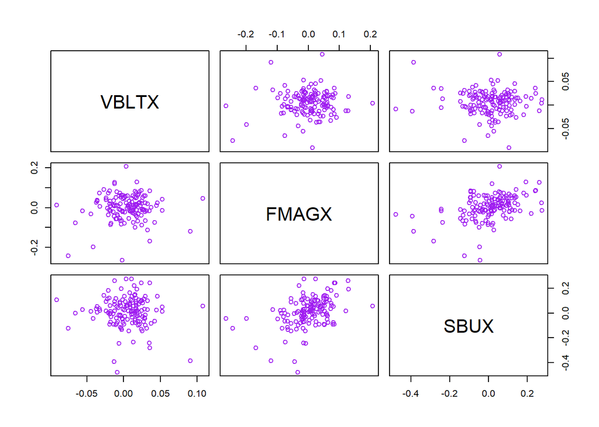

```r
pairs(data_ccreturn, col = "purple")
```

- It seems that there is no relationship between VBLTX and FMGAX, between VBLTX and SBUX. And there is a moderate positive relationship between FMAGX and SBUX.

### (h)

```r
cor(data_ccreturn_m)
```

```
##             VBLTX      FMAGX        SBUX
## VBLTX  1.00000000 0.06375285 -0.05614597
## FMAGX  0.06375285 1.00000000  0.42384131
## SBUX  -0.05614597 0.42384131  1.00000000
```

```r
cov(data_ccreturn_m)
```

```
##               VBLTX        FMAGX          SBUX
## VBLTX  0.0006902688 0.0001073517 -0.0001761177
## FMAGX  0.0001073517 0.0041077189  0.0032432400
## SBUX  -0.0001761177 0.0032432400  0.0142544638
```

- Results are similar to last question, there is almost no linear relationship between VBLTX and FMAGX, between VBLTX and SBUX. And there is a moderate postive relationship between FMAGX and SBUX, which is about 0.4.

### (i)

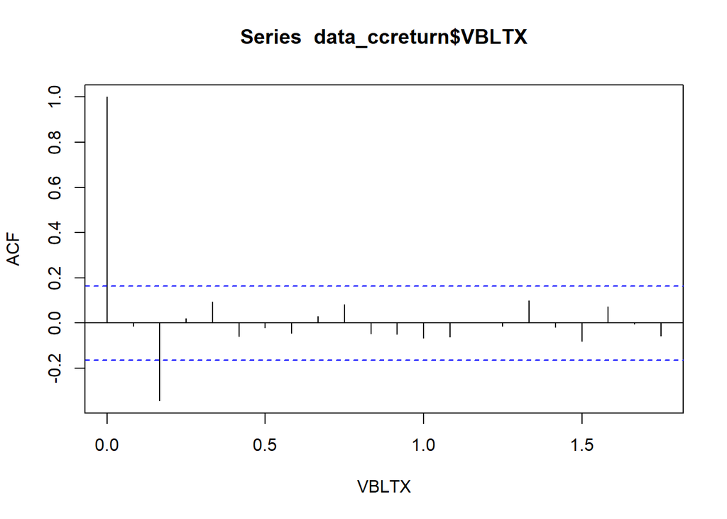

```r
acf(data_ccreturn$VBLTX, xlab = "VBLTX")
```

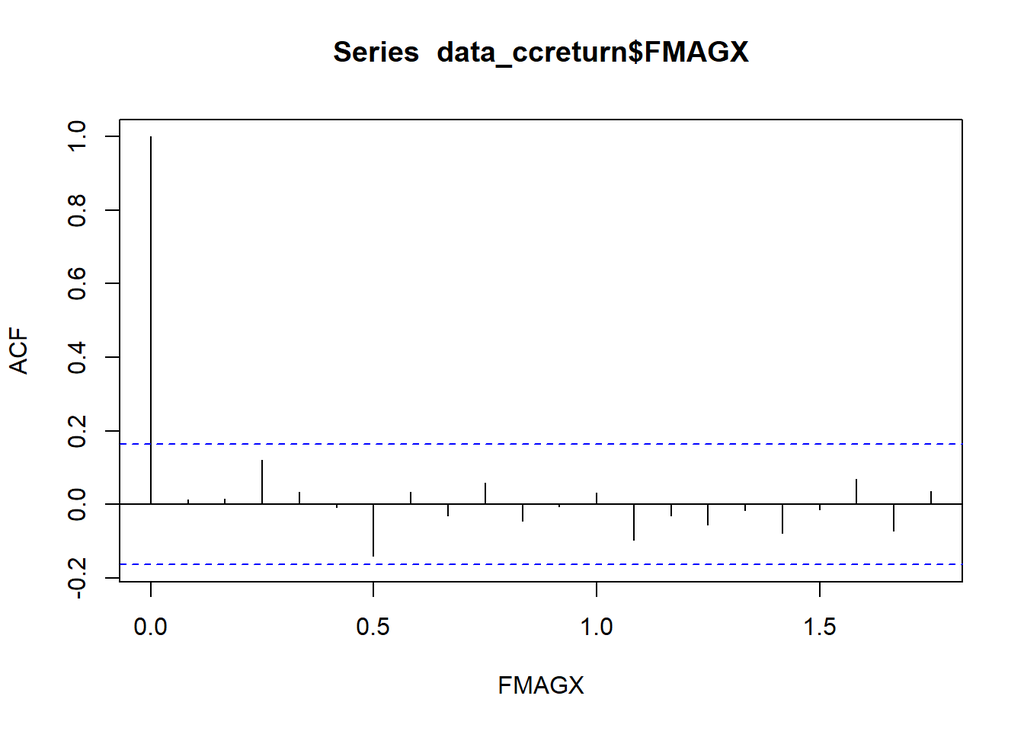

```r
acf(data_ccreturn$FMAGX, xlab = "FMAGX")
```

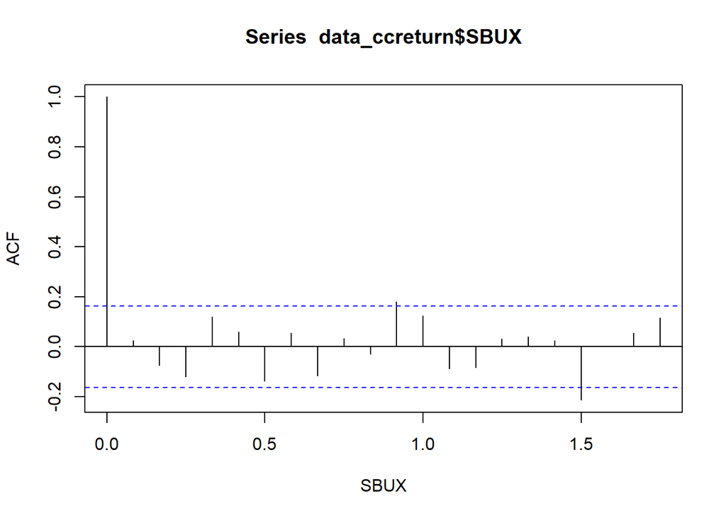

```r
acf(data_ccreturn$SBUX, xlab = "SBUX")
```

- Return of VBLTX appears to be not uncorrelated over time, because it has one peak at lag 2; FMGAX appears to be uncorrelated over time because no values go over 2 stand deviations, SBUX appears to have the largest time dependence.

## 2

### (a)

- Because $\epsilon_{it}\sim N(0,\sigma_i^2)$, from CER model, we can get $R_{it}\sim N(\mu_i,\sigma_i^2)$, so we can get the estimates directly from descriptive statistics.

```r
mu_hat = apply(data_ccreturn, 2, mean)
sigma2_hat = apply(data_ccreturn, 2, var)
sigma_hat = apply(data_ccreturn, 2, sd)
uni_stat = cbind(mu_hat, sigma2_hat, sigma_hat)

cov_hat = cov(data_ccreturn)[lower.tri(cov(data_ccreturn))]
cor_hat = cor(data_ccreturn)[lower.tri(cor(data_ccreturn))]
bi_stat = cbind(cov_hat, cor_hat)
rownames(bi_stat) = c("VBLTX,FMAGX", "VBLTX,SBUX", "FMAGX,SBUX")

print(uni_stat)
```

```
##            mu_hat   sigma2_hat  sigma_hat
## VBLTX 0.005302105 0.0006902688 0.02627297
## FMAGX 0.001856141 0.0041077189 0.06409149
## SBUX  0.011318308 0.0142544638 0.11939206
```

```r
print(bi_stat)
```

```
##                   cov_hat     cor_hat
## VBLTX,FMAGX  0.0001073517  0.06375285
## VBLTX,SBUX  -0.0001761177 -0.05614597
## FMAGX,SBUX   0.0032432400  0.42384131
```

- These estimates are estiamted using the descriptive statistics, so they are actually the same values, hence, comments are same as above questions: SBUX has the highest mean with the highest variance, and VBLTX has higher mean than FMAGX while having lower variance. What’s more, there exists a postive relationship between FMAGX and SBUX.

### (b)

- Formula
  $$\begin{aligned}
  SE(\hat{\mu}) &= \frac{\hat{\sigma}}{\sqrt{T}}\\
  SE(\hat{\sigma}^2) &= \frac{\sqrt{2}\hat{\sigma}^2}{\sqrt{T}}\\
  SE(\hat{\sigma}) &=\frac{\hat{\sigma}}{\sqrt{2T}}\\
  SE(\hat{\rho}) &=\frac{1-\hat{\rho}^2}{\sqrt{T}}
  \end{aligned}$$

```r
period = nrow(data_ccreturn)
se_mu_hat = sigma_hat / sqrt(period)
se_sigma2_hat = sqrt(2) * sigma2_hat / sqrt(period)
se_sigma_hat = sigma_hat / sqrt(2 * period)
se_cor_hat = (1 - cor_hat ^ 2) / sqrt(period)
uni_stat2 = cbind(se_mu_hat, se_sigma2_hat, se_sigma_hat)
bi_stat2 = cbind(se_cor_hat)
rownames(bi_stat2) = c("VBLTX,FMAGX", "VBLTX,SBUX", "FMAGX,SBUX")

uni_stat = cbind(uni_stat, uni_stat2)
bi_stat = cbind(bi_stat, bi_stat2)
print(uni_stat)
```

```
##            mu_hat   sigma2_hat  sigma_hat   se_mu_hat se_sigma2_hat
## VBLTX 0.005302105 0.0006902688 0.02627297 0.002197056  0.0000816329
## FMAGX 0.001856141 0.0041077189 0.06409149 0.005359600  0.0004857890
## SBUX  0.011318308 0.0142544638 0.11939206 0.009984066  0.0016857682
##       se_sigma_hat
## VBLTX  0.001553553
## FMAGX  0.003789809
## SBUX   0.007059800
```

```r
print(bi_stat)
```

```
##                   cov_hat     cor_hat se_cor_hat
## VBLTX,FMAGX  0.0001073517  0.06375285 0.08328432
## VBLTX,SBUX  -0.0001761177 -0.05614597 0.08336059
## FMAGX,SBUX   0.0032432400  0.42384131 0.06860183
```

- From the magnitude of the standard error and mean, we can conclude that $\hat{\mu}$ is not precise; $\hat{\sigma},\hat{\sigma}^2$, estimates for three assets are precise; for $\hat{\rho}$, only the correlation between FMAGX and SBUX is precise.

### (c)

-Formula
$$C.I(\hat{\theta}) = \hat{\theta} \pm t_{1-\frac{\alpha}{2}}(T-1) * SE(\hat{\theta})$$

```r
freedom = period - 1

ci = function(mu, se, q1, q2) {
  lower = mu - qt(q1, freedom) * se
  upper = mu + qt(q1, freedom) * se
  lower2 = mu - qt(q2, freedom) * se
  upper2 = mu + qt(q2, freedom) * se
  ci_m = cbind(lower, upper, lower2, upper2)
  colnames(ci_m) = c(str_c(c("lower_", "upper_", "lower_", "upper_"), c(1 - 2*(1 - q1), 1 - 2*(1 - q1), 1 - 2*(1 - q2), 1 - 2*(1 - q2))))
  return (ci_m)
}
ci_mu = ci(uni_stat[, 1], uni_stat[, 4], 0.975, 0.995)
ci_sigma2 = ci(uni_stat[, 2], uni_stat[, 5], 0.975, 0.995)
ci_sigma = ci(uni_stat[, 3], uni_stat[, 6], 0.975, 0.995)
ci_cor = ci(bi_stat[, 2], bi_stat[, 3], 0.975, 0.995)
print(ci_mu)
```

```
##          lower_0.95  upper_0.95    lower_0.99 upper_0.99
## VBLTX  0.0009589406 0.009645269 -0.0004341781 0.01103839
## FMAGX -0.0087387742 0.012451056 -0.0121372122 0.01584949
## SBUX  -0.0084183029 0.031054918 -0.0147490421 0.03738566
```

```r
print(ci_sigma2)
```

```
##        lower_0.95   upper_0.95   lower_0.99   upper_0.99
## VBLTX 0.000528896 0.0008516416 0.0004771338 0.0009034037
## FMAGX 0.003147406 0.0050680320 0.0028393746 0.0053760632
## SBUX  0.010922019 0.0175869089 0.0098530994 0.0186558281
```

```r
print(ci_sigma)
```

```
##       lower_0.95 upper_0.95 lower_0.99 upper_0.99
## VBLTX 0.02320189 0.02934405 0.02221680 0.03032913
## FMAGX 0.05659975 0.07158323 0.05419669 0.07398628
## SBUX  0.10543617 0.13334795 0.10095966 0.13782446
```

```r
print(ci_cor)
```

```
##             lower_0.95 upper_0.95 lower_0.99 upper_0.99
## VBLTX,FMAGX -0.1008845  0.2283902 -0.1536938  0.2811995
## VBLTX,SBUX  -0.2209341  0.1086422 -0.2737917  0.1614998
## FMAGX,SBUX   0.2882285  0.5594542  0.2447291  0.6029535
```

- We can get similar results as the above question. For $\mu$, c.i are very wide; for $\sigma^2, \sigma$, c.i is narrow for each aseet; for $\rho$, c.i is also so wide.

### (d)

When $r$ is the cc return, we can use Lemma 2:

$$Lemma2: VAR(W_0) = W_0 * [e^{q^r} -1]$$

```r
W = 1e5
VAR_0.05 = 1e5 * (exp(qnorm(0.05, mu_hat, sigma_hat)) - 1)
VAR_0.01 = 1e5 * (exp(qnorm(0.01, mu_hat, sigma_hat)) - 1)
print(VAR_0.05)
```

```
##      VBLTX      FMAGX       SBUX
##  -3720.338  -9838.256 -16894.903
```

```r
print(VAR_0.01)
```

```
##      VBLTX      FMAGX       SBUX
##  -5428.872 -13691.574 -23388.972
```

- We conclude that VBLTX has the least VaR.